# Introducing Idealstan, an R Package for Bayesian Inference of Ideal Point Models

Robert Kubinec PhD Candidate Department of Politics University of Virginia

January 11, 2018

## Latent Variable Models

- Latent variable: an unobserved quantity
- Data: indicators that have a relationship to the latent variable
- Uncertainty in the latent variable never goes away

## Latent Variables = Many Names

- Measurement Models
- Factor Analysis
- Principal Component Analysis
- Structural Equation Modeling
- Item-Response Theory
- Heckman Selection Models (Also Tobit)
- Hidden-Markov Models
- Ideal Point Models
- Multi-Dimensional Scaling
- Latent Space Models
- Or even just Missing Data (Rubin & Friends)

## Ideal Point Modeling: A Hierarchical Latent Variable Model

- Ideal Point models and item-response theory are similar in that they don’t treat the rows and columns the same
- In IRT speak, the rows are “persons” and the columns are “items”.
- The items are used to discriminate between the persons along the scale of the latent variable
- IRT and ideal point models differ in how they understand how to place the persons along the latent scale
- In IRT, higher values of the observable indicators = higher values of the latent variable, but in ideal point models this is not necessarily true.

## Ideal Point Model Graphic

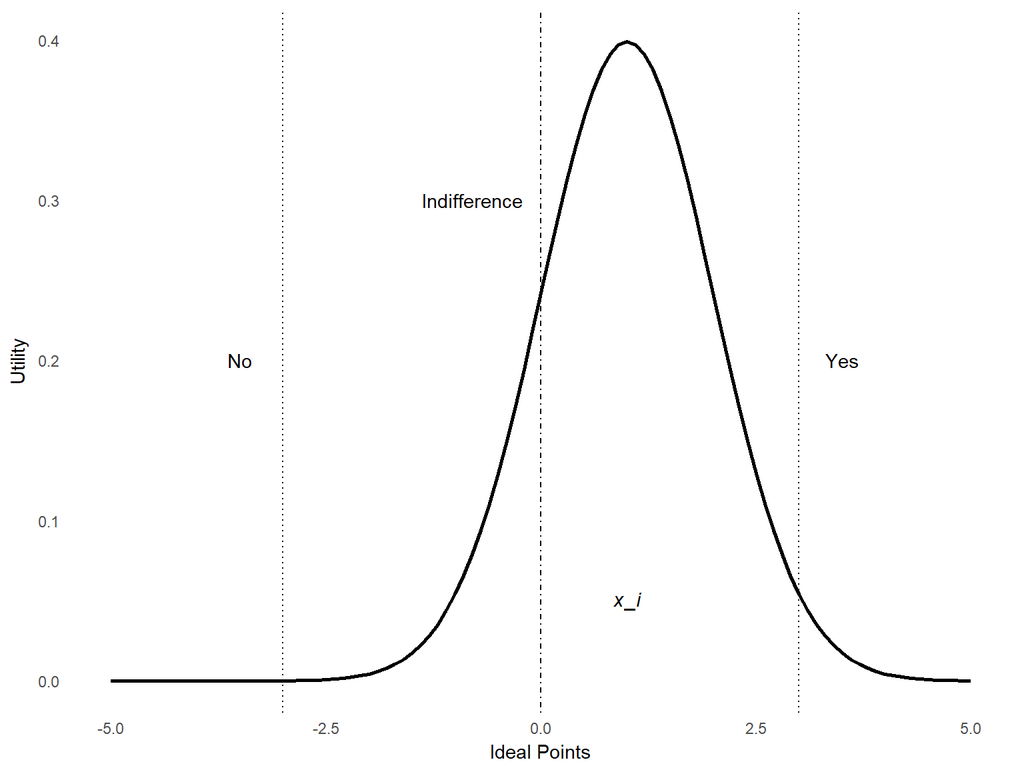

## Using IRT as an Estimation

- We can represent this theory using IRT:

$$Y_{ij} = \alpha_j x_i - \beta_j$$

- $\alpha_j =$ Discrimination parameters
- $x_i =$ Ideal points
- $\beta_j$ Difficulty parameters
- *BUT* $\alpha_j \in \mathbb{R}$ *not* $\alpha_j \in \mathbb{R}^{+}$
- $\frac{\beta_j}{\alpha_j}$ Line of indifference

## But it’s not IDENTIFIED!!!1!!!!1!

- Bayesian modeling is much more naturally able to handle latent variables of this kind.
- Maximum Likelihood solutions exist, but they tend to be ad hoc.

## We Can… Find a Local Maximum?

[figure not shown]

## Enter Idealstan

- Currently offers binary and ordinal IRT ideal point models.
- Missing-data inference is built in (using a particular parametric form–see paper).
- Plotting functions for ideal points + predictive posterior checking + LOO-CV with `loo`
- Identification either pre-specified or through variational inference (`vb`)

## Example: Coffee

- I used an existing corpus of [Amazon food reviews from 2013 by McAuley and Leskovec](https://snap.stanford.edu/data/web-FineFoods.html).
- Each review has a 5-star ranking: ordinal outcome.
- I kept all reviews that mentioned coffee at least a few times.
- We have 11,269 rows (raters-persons-$x_i$) and 429 columns (coffee products-items-$\alpha_j$ and $\beta_j$)

## How Does Coffee Divide People?

[figure not shown]

## Result: Coffee Reviewers Ideal Point Distribution

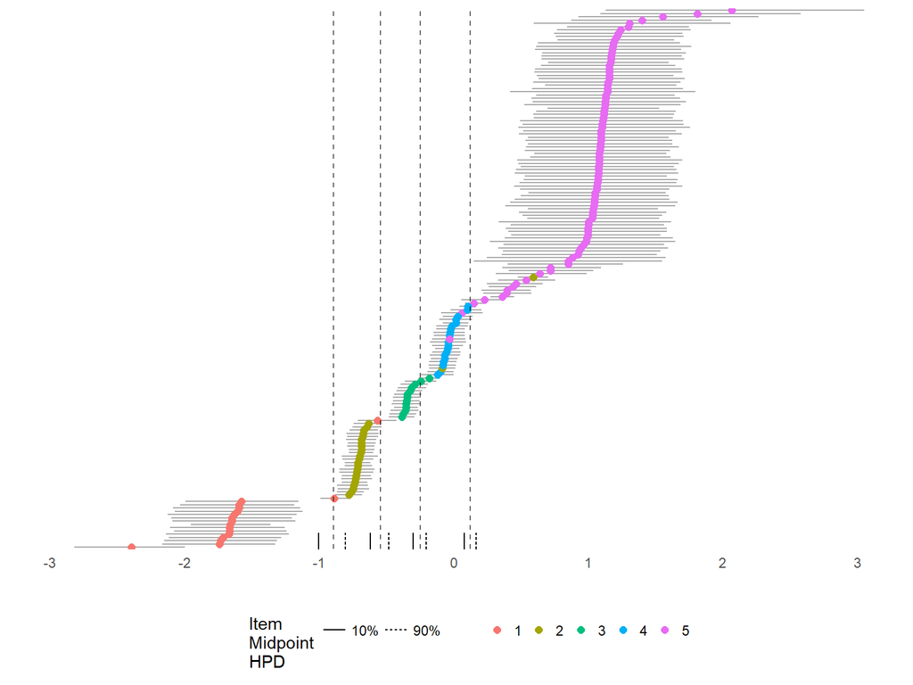

## Most Polarizing Coffees

|  | Product Description | Discrimination |
| --- | --- | --- |
| 1 | Kicking Horse Coffee 454 Horse Power Dark, Whole Bean | 7.87259 |
| 2 | Amazing Grass Green Superfood Organic Powder | 7.864585 |
| 3 | Starbucks Via Ready Brew Instant Coffee | 7.80567 |
| 4 | Stephen's Gourmet Hot Cocoa, Candycane Cocoa | 7.805575 |
| 5 | Prince of Peace Organic Tea, Oolong | 7.770375 |
| 6 | NOW Foods Erythritol Natural Sweetener | 7.770345 |
| 7 | illy Cappucino, 12 pack | 7.727985 |
| 8 | Nestle Hot Cocoa Mix | 7.33822 |
| 9 | Better than Milk Vegan Soy Powder | 7.33797 |
| 10 | Ghirardelli Chocolate Sweet Ground Chocolate &amp; Cocoa | 7.28447 |

## But Wait… Missing Data?

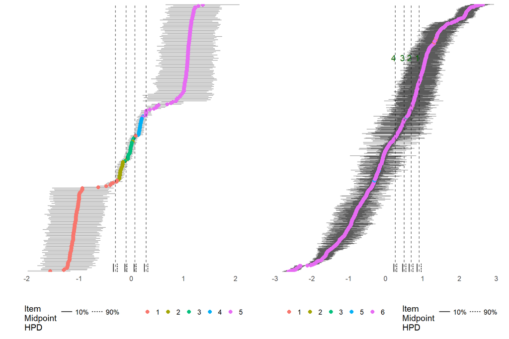

## Coming Next

- V0.2 (first stable release) on [Github](https://github.com/saudiwin/idealstan), CRAN version coming soon.
- Hierarchical models (latent regression)
- Time-series IRT
- Marginal `loo`
- True vs. actual identification
- Whatever we can dream up